# Visualization

# 4 · Adding summaries and uncertainty

## Participant values and group summaries

**Question:** What is the average week-12 SBP in each arm, and how uncertain is it?

1. Keep the participant-level data visible.
2. Calculate an arm-level summary table.
3. Draw a summary layer from that table.
4. State what its interval means.

The raw data and summary layers have different observation units.

## What do these error bars tell us?

60 SECONDS · THINK, THEN VOTE

A caption says: **“Mean week-12 SBP with a 95% confidence interval for each arm mean.”**

**A.** The interval contains 95% of participant SBP values

**B.** It describes uncertainty about each arm’s population mean

**C.** It shows the minimum and maximum SBP

**B.** A confidence interval for a mean concerns that population mean.

The individual points show participant-level variation.

## What do the intervals mean?

| Interval | Describes |
| --- | --- |
| Mean ± SD | Spread of individual measurements around their mean |
| Mean ± SE | Estimated sampling variability of the mean |
| Confidence interval | Uncertainty about a population parameter under a model |
| Prediction interval | Uncertainty about a new individual observation |

The same `geom_errorbar()` can draw any of these. Its inputs do not tell the reader which one you intended. State the meaning and method in the caption.

The earlier `mean ± 1.96 * SE` examples use an approximate 95% confidence interval. The longitudinal ribbon gives intervals at each visit, not a model of change.

## Uncertainty: an estimate needs an interval

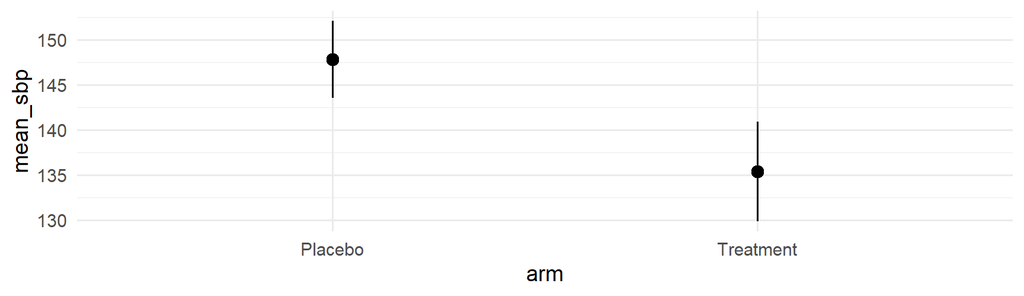

```r
by_arm <- trial |>
  group_by(arm) |>
  summarise(mean_sbp = mean(sbp_12),
            se = sd(sbp_12) / sqrt(n()))

ggplot(by_arm, aes(arm, mean_sbp)) +
  geom_pointrange(aes(ymin = mean_sbp - 1.96 * se,
                      ymax = mean_sbp + 1.96 * se))
```

## A layer can use its own data

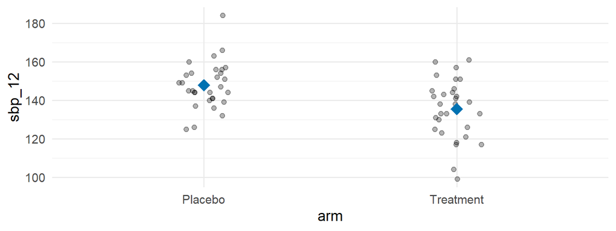

```r
ggplot(trial, aes(arm, sbp_12)) +
  geom_point(position = position_jitter(width = 0.1, height = 0,
                                        seed = 6301), alpha = 0.3) +
  geom_point(data = by_arm, aes(x = arm, y = mean_sbp),
             inherit.aes = FALSE, shape = 18, size = 5,
             colour = "#0072B2")
```

Grey points use participant data. Blue diamonds use the summary table. `inherit.aes = FALSE` makes the summary layer use only its own mappings.

## Relationships: points and a smooth

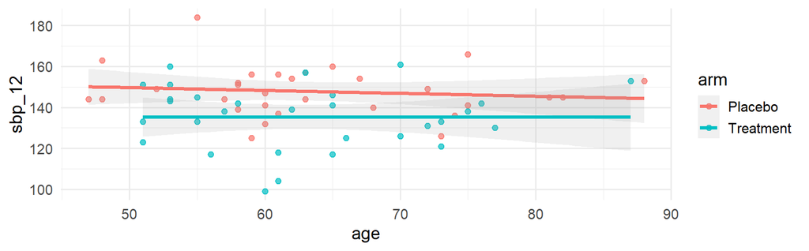

```r
ggplot(trial, aes(age, sbp_12, colour = arm)) +
  geom_point(alpha = 0.7) +
  geom_smooth(method = "lm", se = TRUE, alpha = 0.15)
```

`method = "lm"` specifies a linear fit. With `method = NULL`, ggplot2 chooses loess or GAM according to the largest group’s size. The band describes uncertainty in the fitted mean, not a prediction interval for an individual.

## Layer-specific mappings

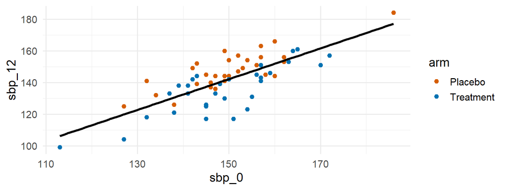

```r
ggplot(trial, aes(sbp_0, sbp_12)) +
  geom_point(aes(colour = arm)) +
  geom_smooth(method = "lm", se = FALSE, colour = "black") +
  scale_colour_manual(values = arm_col)
```

Colour belongs only to the points here. The smooth uses all participants together. Putting `colour = arm` in the global `aes()` would fit one line per arm.

# 5 · Showing repeated visits

## A new question needs a different data shape

**Question:** How does blood pressure change over the three visits?

- One row in `trial`: one participant, with visits in separate columns.
- One row in `trial_long`: one participant at one visit.
- Individual lines need `id`, `week`, and `sbp`.
- Group-average lines need an arm-by-week summary.

Session 7’s wide-to-long reshape makes these plots easier to specify.

## Did reshaping triple our study?

75 SECONDS · THINK, THEN COMPARE

There are **60 participants** and **three visits per participant**: weeks 0, 6, and 12.

After reshaping to long form:

1. How many rows do we have?
2. How many participants do we have?
3. Which variable keeps each person’s line together?

**180 rows, 60 participants, and `group = id` for individual trajectories.**

One long-table row represents one participant at one visit.

## Plotting repeated visits uses the long table

```r
trial_long <- trial |>
  select(id, arm, sbp_0, sbp_6, sbp_12) |>
  tidyr::pivot_longer(starts_with("sbp_"),
                     names_to = "week", names_prefix = "sbp_",
                     values_to = "sbp") |>
  mutate(week = as.numeric(week))
```

| id | arm | week | sbp |
| --- | --- | --- | --- |
| P001 | Placebo | 0 | 160 |
| P001 | Placebo | 6 | 146 |
| P001 | Placebo | 12 | 144 |

The first participant contributes three rows. Their shared `id` tells the plot which measurements belong together.

## One line per participant

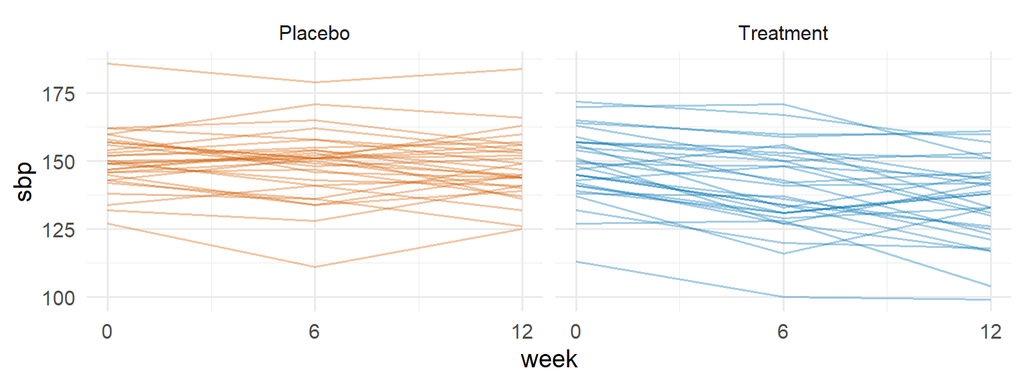

```r
ggplot(trial_long, aes(week, sbp, group = id, colour = arm)) +
  geom_line(alpha = 0.35) +
  facet_wrap(~ arm) +
  scale_x_continuous(breaks = c(0, 6, 12)) +
  scale_colour_manual(values = arm_col, guide = "none")
```

`colour = arm` alone would define only two colour groups. `group = id` tells the line layer to connect each person’s own measurements.

## Optional: line versus path

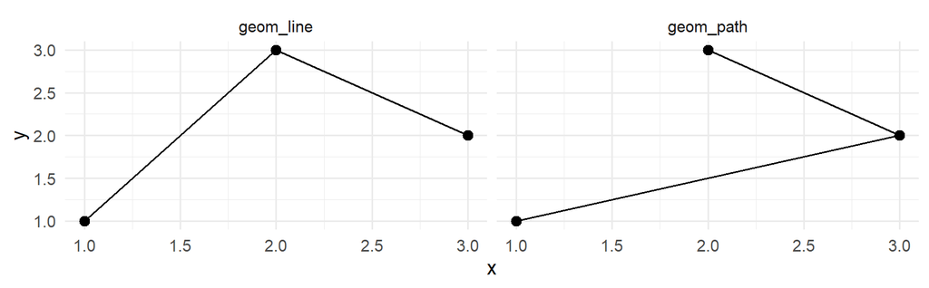

```r
route <- data.frame(x = c(1, 3, 2), y = c(1, 2, 3))
routes <- rbind(transform(route, display = "geom_line"),
                transform(route, display = "geom_path"))
ggplot(routes, aes(x, y)) +
  geom_point(size = 3) +
  geom_line(data = subset(routes, display == "geom_line")) +
  geom_path(data = subset(routes, display == "geom_path")) +
  facet_wrap(~ display)
```

`geom_line()` sorts by x within each group. `geom_path()` follows row order, which is useful for an ordered route through space.

## Uncertainty over time: the ribbon

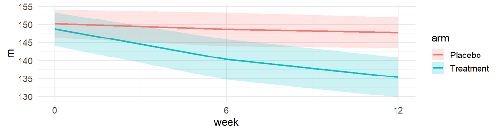

```r
by_week <- trial_long |>
  group_by(arm, week) |>
  summarise(m = mean(sbp), se = sd(sbp) / sqrt(n()),
            .groups = "drop")

ggplot(by_week, aes(week, m, colour = arm, fill = arm)) +
  geom_ribbon(aes(ymin = m - 1.96 * se, ymax = m + 1.96 * se),
              alpha = 0.2, colour = NA) +
  geom_line(linewidth = 1) +
  scale_x_continuous(breaks = c(0, 6, 12))
```

## Facets: the same plot, split

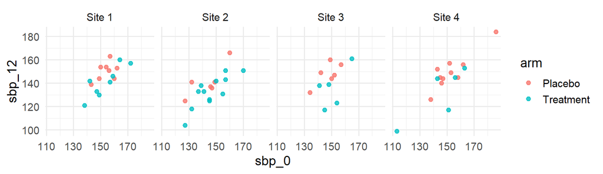

```r
ggplot(trial, aes(sbp_0, sbp_12, colour = arm)) +
  geom_point(alpha = 0.8) +
  facet_wrap(~ site_f, nrow = 1)
```

`facet_wrap(~ x)` wraps one variable into panels · `facet_grid(a ~ b)` makes a matrix of two · `scales = "free_y"` lets each panel set its own axis, **which breaks comparability**.

# 6 · Refining the display

## Display choices after the plot works

Our plot already answers a question. Now consider how readers will interpret it.

- Would a transformation make a skewed variable easier to see?
- Do we want to zoom, or intentionally exclude data?
- Can the reader identify groups and understand the labels?
- Will the exported figure remain readable at its final size?

## Scales: where the transformation belongs

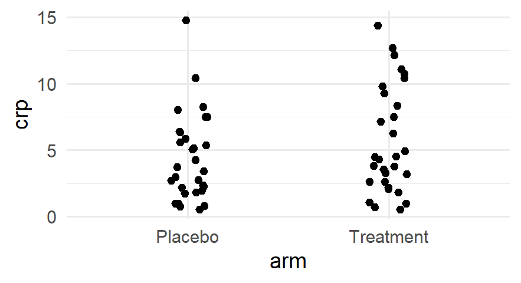

```r
ggplot(trial, aes(arm, crp)) +
  geom_jitter(width = 0.1)
```

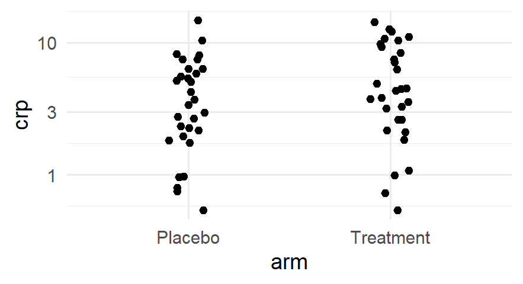

```r
ggplot(trial, aes(arm, crp)) +
  geom_jitter(width = 0.1) +
  scale_y_log10()
```

`scale_y_log10()` transforms the **scale** and keeps the axis in original units. `aes(y = log10(crp))` transforms the **data** and labels the axis `log10(crp)`. Prefer the scale.

## Will these give the same boxplot?

75 SECONDS · PREDICT, THEN DISCUSS

```r
p <- ggplot(trial, aes(arm, sbp_12)) + geom_boxplot()

# A
p + coord_cartesian(ylim = c(120, 160))

# B
p + scale_y_continuous(limits = c(120, 160))
```

**Which keeps all observations in the boxplot calculation?**

**A.** Coordinate zoom keeps the data used to calculate the boxplot.

In B, out-of-range values become missing before the calculation, so the summary can change.

## Zooming versus removing observations

```r
p <- ggplot(trial, aes(arm, sbp_12)) + geom_boxplot()

p + coord_cartesian(ylim = c(120, 160))  # zoom after calculation
p + scale_y_continuous(limits = c(120, 160))
# Out-of-range values become NA before the boxplot calculation
```

- Zooming retains the full data in the statistical calculation.
- Scale limits can change quartiles, smooths, and other calculated summaries.
- If exclusion is intentional, filter the data explicitly and explain why.

## Optional: a small heatmap

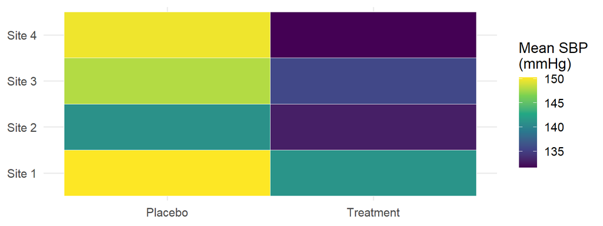

```r
site_summary <- trial |>
  group_by(site_f, arm) |>
  summarise(mean_sbp = mean(sbp_12), .groups = "drop")
ggplot(site_summary, aes(arm, site_f, fill = mean_sbp)) +
  geom_tile(colour = "white") +
  scale_fill_viridis_c() +
  labs(x = NULL, y = NULL, fill = "Mean SBP\n(mmHg)")
```

Each cell represents a site/arm summary. Heatmaps show patterns across many combinations; a dot plot is easier for precise comparisons of a few estimates.

## A debugging checklist for plots

| Symptom | First check |
| --- | --- |
| Unexpected colour legend | Did a constant go inside `aes()`? |
| One line connects different people | Is `group = id` specified? |
| Bar heights are unexpected | Does the geom count rows or use supplied y? |
| “Removed rows” warning | Missing values or scale limits? |
| Labels or layers disappear | Axis limits, layer data, and inherited mappings |
| Plot does not appear after assignment | Print the saved plot object: `p` |

Read the warning and inspect the relevant data before using `na.rm = TRUE` to suppress a message.

# 7 · Critiquing and improving a figure

## The perceptual hierarchy

How accurately a reader can decode a quantity, best first:

| Rank | Channel | Use it for |
| --- | --- | --- |
| 1 | **Position** on a common scale | The number that carries your argument |
| 2 | **Length** | Second choice; needs a zero baseline |
| 3 | Angle, slope | Trends, reluctantly |
| 4 | **Area** | Rough magnitude only |
| 5 | Colour intensity, saturation | Broad patterns or a third variable |

For precise comparisons, prefer positions on a shared axis. Colour remains useful for group identity and for patterns across large matrices.

## Critique: what is wrong here?

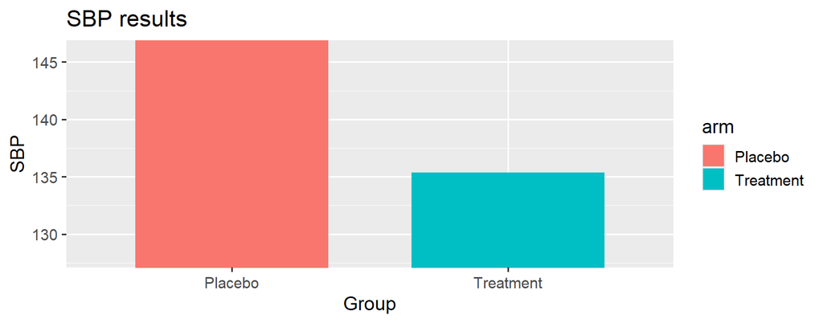

**Think for 20 seconds. Compare with a neighbor for 30 seconds.**

Name one specific choice and the mistaken impression it could create.

## The same data, honestly

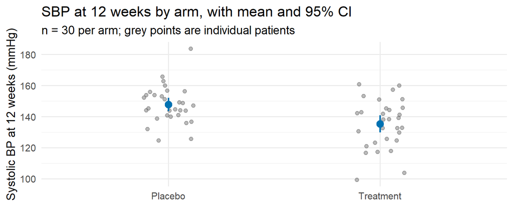

## Pie charts and dual axes need care

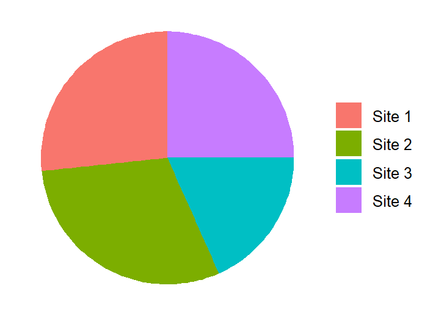

**Pie charts** ask the reader to compare **angles and areas** — ranks 3 and 4. Rank the four sites from that. Now imagine a bar chart.

**Dual axes** are worse, because the reader cannot check them:

```r
# do not
p + scale_y_continuous(
  sec.axis = sec_axis(~ . * 3.2, name = "CRP")
)
```

The crossing point is set by *your* choice of scaling. Two facets, or two panels, say the same thing without the implied claim.

## What survives a grayscale printout?

60 SECONDS · THINK, THEN VOTE

A scatterplot identifies the two treatment arms using **colour alone**.

If those colours become indistinguishable, what could preserve the group information?

**A.** A larger title

**B.** Different point shapes or separate labelled panels

**C.** Thicker grid lines

**B.** Shape or labelled panels provide another way to identify the arms.

A suitable palette helps; the group meaning should also survive without colour.

## Colour-blind-safe, on purpose

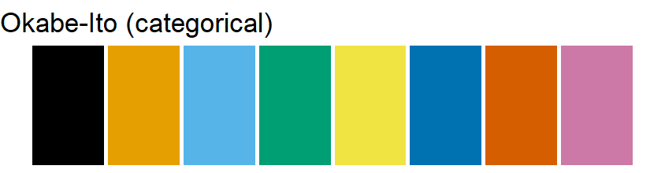

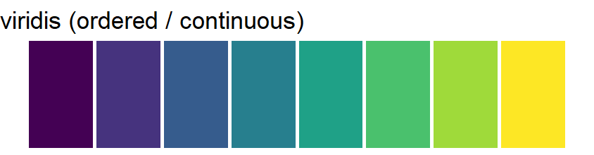

```r
# categorical - built in to R since 4.0
palette.colors(8, "Okabe-Ito")
```

```
#> #000000 #E69F00 #56B4E9 #009E73 #F0E442 #0072B2 #D55E00 #CC79A7
```

```r
scale_colour_manual(values = palette.colors(3, "Okabe-Ito"))

# ordered or continuous - built in to ggplot2
scale_colour_viridis_d()   # discrete
scale_fill_viridis_c()     # continuous
```

Then print it in greyscale. If the groups stop being distinguishable, colour was doing work that shape or a direct label should have been doing.

## Label the thing, not the legend

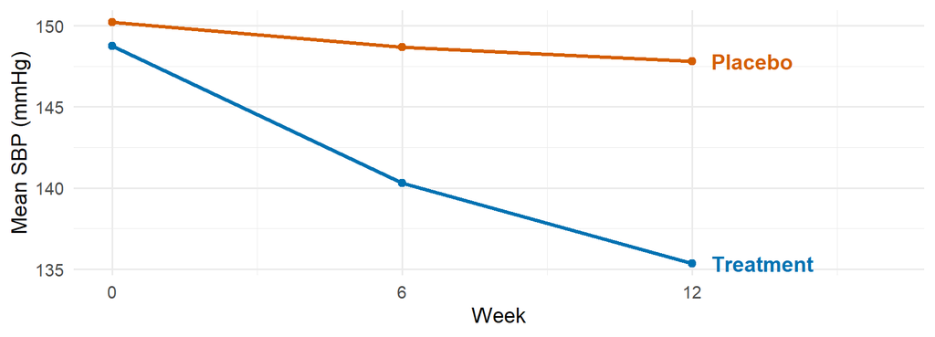

A legend makes the reader look away, decode, and look back — for every series. A label next to the line costs them nothing.

## Ink that is not information

Every mark on a figure is either **carrying information** or **competing with it**.

| Remove | Because |
| --- | --- |
| Heavy grid lines, panel background | They are as visually loud as the data |
| A legend that repeats the x axis | Zero information |
| A third dimension on a 2-D quantity | Distorts area and hides marks |
| Decorative colour | Spends the strongest labelling channel on nothing |
| Gridlines on a categorical axis | There is nothing to read off |

`theme_minimal()` gets you most of the way for free. The rest is deletion, and the test is: **remove it. Did the figure lose anything?**

# 8 · Exporting the final figure

## Finish it: `labs()` and a theme

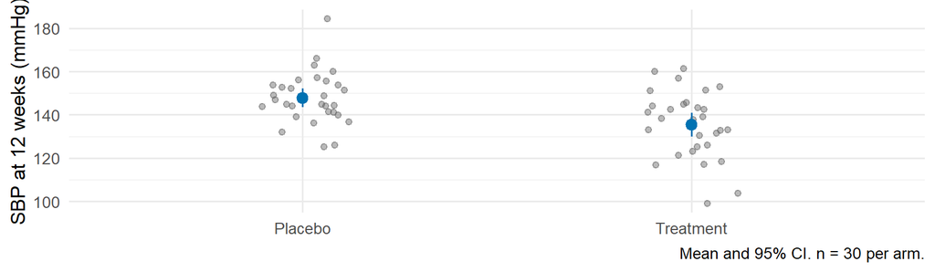

```r
p_final <- ggplot(trial, aes(arm, sbp_12)) +
  geom_jitter(width = 0.12, alpha = 0.45, colour = "grey40") +
  geom_pointrange(data = by_arm,
                  aes(y = mean_sbp,
                      ymin = mean_sbp - 1.96 * se,
                      ymax = mean_sbp + 1.96 * se),
                  colour = "#0072B2") +
  labs(x = NULL, y = "SBP at 12 weeks (mmHg)",
       caption = "Mean and 95% CI. n = 30 per arm.") +
  theme_minimal(base_size = 13)
p_final
```

## Same code, different-sized figures?

60 SECONDS · THINK, THEN VOTE

Two collaborators run:

```r
ggsave("figure.png", plot = p_final)
```

Their RStudio plot panes have different dimensions.

**Could the saved figures have different dimensions too?**

**Yes.** Without explicit width and height, the export can use the current graphics device’s size.

Specify `width`, `height`, and `units`; choose DPI for a raster export.

## `ggsave()`, with the arguments filled in

```r
dir.create("output", showWarnings = FALSE)
ggsave(
  filename = "output/fig-sbp-arm.png",
  plot     = p_final,
  width    = 6.5,     # inches - the column width of your journal
  height   = 4, units = "in",
  dpi      = 300,     # pixels per inch for this raster PNG
  bg       = "white"
)
```

| Argument | Leave it out and you get |
| --- | --- |
| `width`, `height` | The last size of your **plot pane**. Irreproducible by construction |
| `dpi` | PNG pixel density defaults to 300; it does not set vector PDF sharpness |
| `bg` | Background comes from the plot theme and may be transparent |
| `.pdf` / `.svg` extension | Vector marks scale without pixelation; embedded raster layers still have finite resolution |

## PNG versus PDF with `ggsave()`

```r
# Raster: 6 x 4 inches at 300 DPI = 1800 x 1200 pixels
ggsave("output/figure.png", plot = p_final,
       width = 6, height = 4, units = "in", dpi = 300)

# Vector: 6 x 4 inch page; no raster DPI is needed
ggsave("output/figure.pdf", plot = p_final,
       width = 6, height = 4, units = "in")
```

For PDF at a fixed size in inches, changing `dpi` does **not** sharpen vector lines or text.

With `units = "px"`, `ggsave()` uses `dpi` to convert pixel dimensions to physical size, even for PDF. Prefer inches or cm for vector exports.

## Why the plot pane is not a workflow

### Export → paste

Right-click, copy, paste into Word.

**Nothing records what produced it.** The data changes, the figure does not, and no warning appears anywhere.

### `ggsave()` in the document

The figure is regenerated when its code executes during rendering.

The script records the data and plotting steps. Check data versions and caching settings so the figure stays aligned with the analysis.

A pasted figure is the same class of error as a number typed by hand — and it is harder to spot, because a stale figure still looks like a figure.

## `patchwork`: several panels, one figure

```r
library(patchwork)

p_box  <- ggplot(trial, aes(arm, sbp_12)) + geom_boxplot()
p_scat <- ggplot(trial, aes(sbp_0, sbp_12)) + geom_point()
p_time <- ggplot(by_week, aes(week, m, colour = arm)) + geom_line()

(p_box | p_scat) / p_time +
  plot_annotation(tag_levels = "A")
```

`|` side by side · `/` stacked · `plot_annotation(tag_levels = "A")` labels the panels **A**, **B**, **C** the way a journal wants them.

Optional extension package: `install.packages("patchwork")` if needed.

## Summary

- Choose a figure from the statistical question and observation unit.
- Base R supports complete figures with drawing commands, annotations, and file devices.
- A ggplot is a specification of mappings, layers, scales, coordinates, facets, and theme.
- Mapping a variable differs from setting a display property.
- Show distributions and uncertainty rather than only summary bars.
- Exported dimensions, labels, accessibility, and reproducibility are part of the figure.

**Next connection:** Session 9 introduces Positron and GitHub Copilot; course-approved AI use begins only under that session’s policy.

## Function references

- [Base R graphics and graphical parameters](https://stat.ethz.ch/R-manual/R-devel/library/graphics/html/par.html)
- [Base R plot()](https://stat.ethz.ch/R-manual/R-devel/library/graphics/html/plot.default.html)
- [ggplot2 functions and geoms](https://ggplot2.tidyverse.org/reference/index.html)
- [ggplot2 smoothing methods](https://ggplot2.tidyverse.org/reference/geom_smooth.html)
- [ggplot2 interval geoms](https://ggplot2.tidyverse.org/reference/geom_linerange.html)
- [ggplot2 export with ggsave()](https://ggplot2.tidyverse.org/reference/ggsave.html)

The geom catalogue records the local package version and checks that every exported `geom_*()` name has an entry when the deck renders.